# Case Study

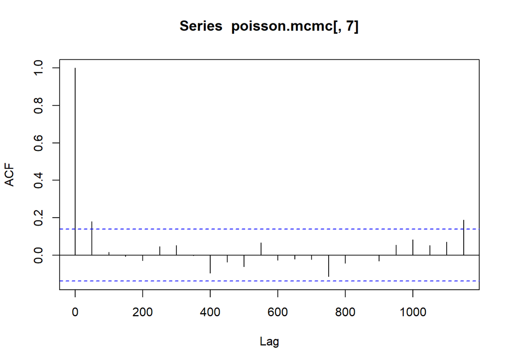

```r
acf(poisson.mcmc[,7])
```

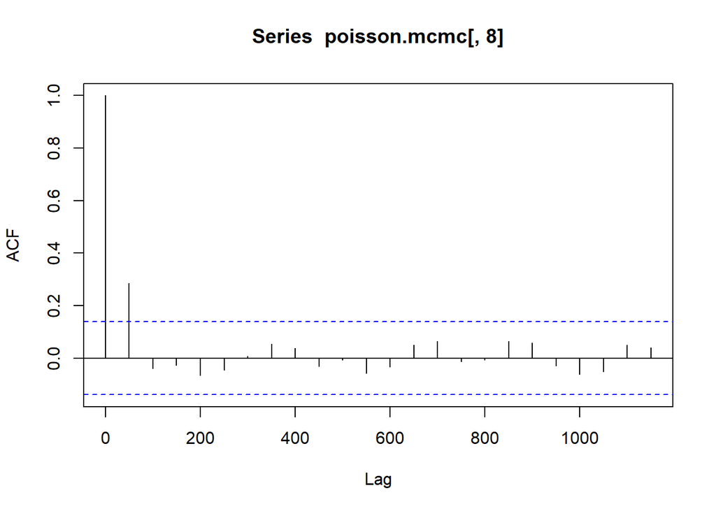

```r
acf(poisson.mcmc[,8])
```

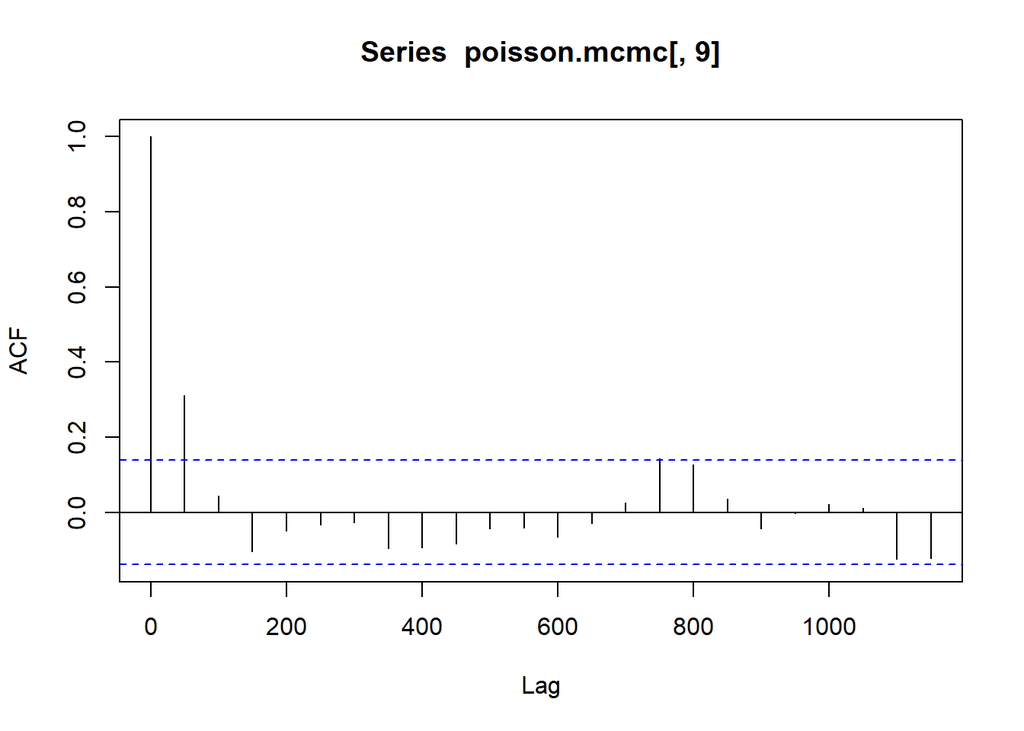

```r
acf(poisson.mcmc[,9])
```

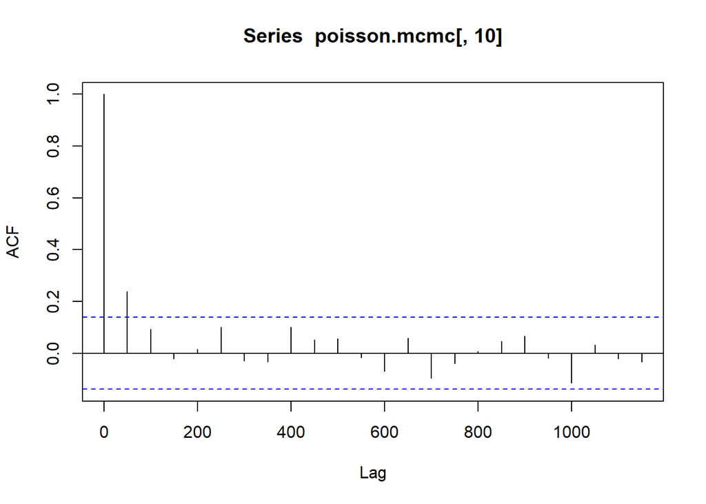

```r
acf(poisson.mcmc[,10])
```

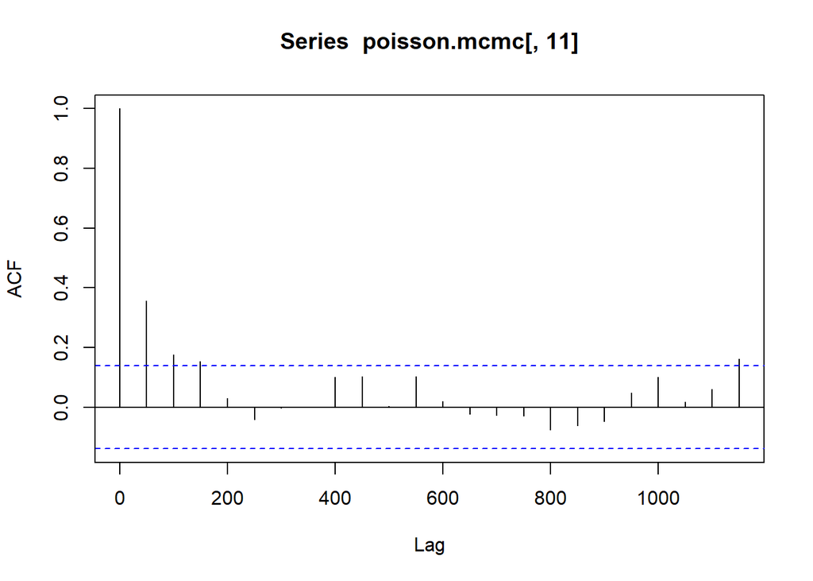

```r
acf(poisson.mcmc[,11])
```

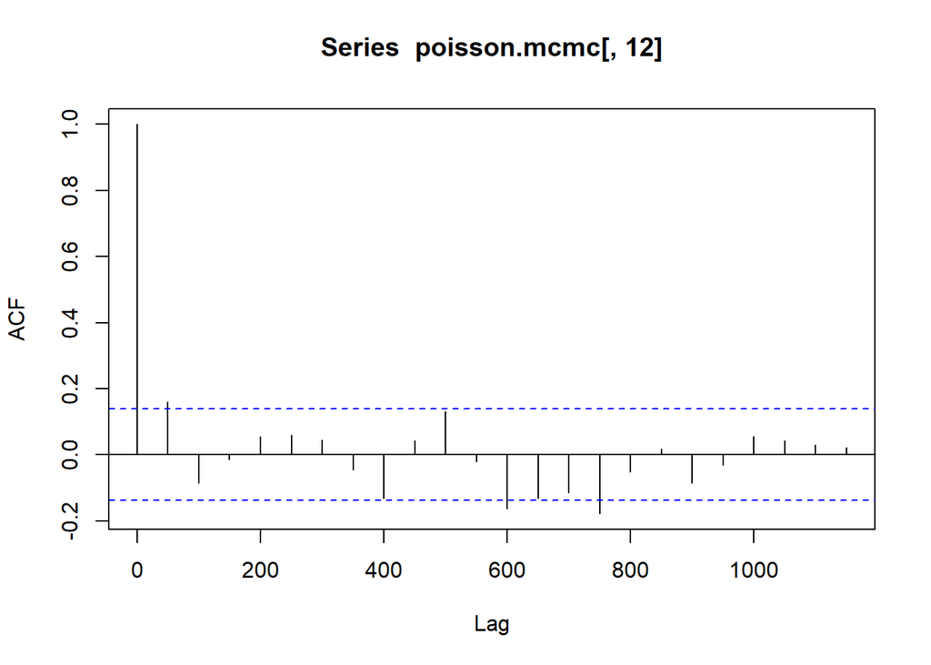

```r
acf(poisson.mcmc[,12])
```

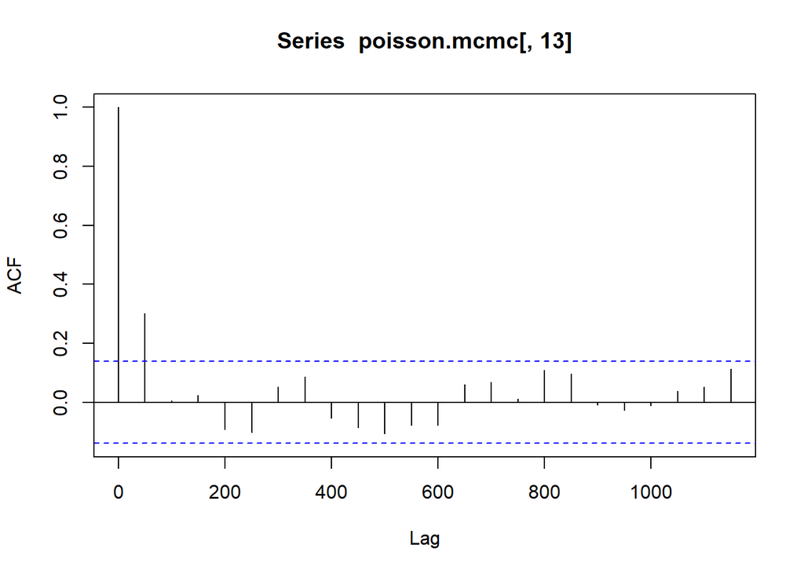

```r
acf(poisson.mcmc[,13])
```

Now our Bayesian Poisson regression model looks correct so we can use it now to obtain the predictive distribution of the number of total rentals given the used variables. For example, what is the predictive distribution for the number of rentals given that we are in the morning of a working Fall day,the weather is misty, and registered=7 and casual=5

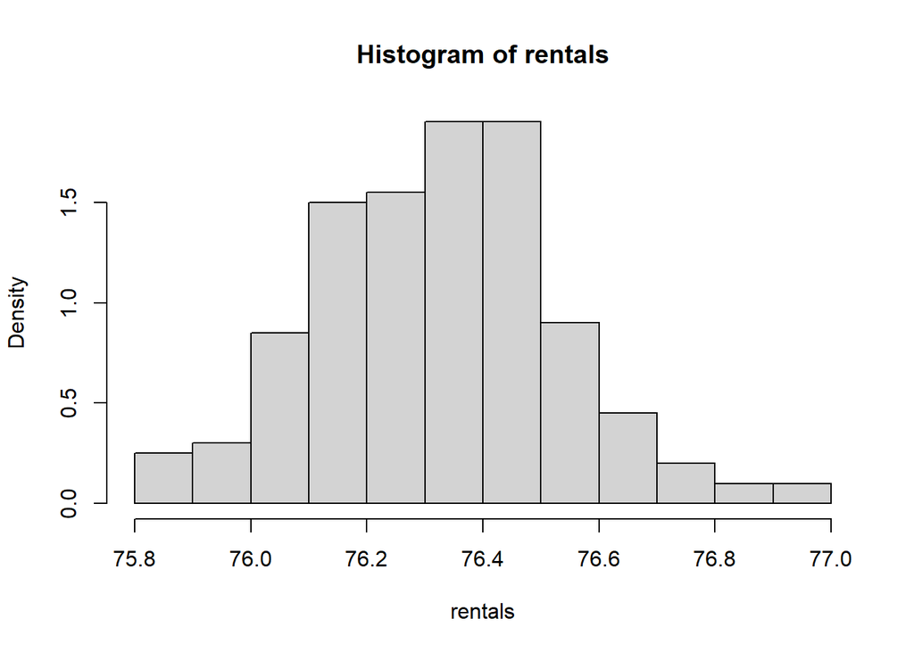

```r
rentals=exp(poisson.mcmc[,1]+poisson.mcmc[,3]+poisson.mcmc[,6]+poisson.mcmc[,8]+poisson.mcmc[,9]+7*poisson.mcmc[,12]+5*poisson.mcmc[,13])
hist(rentals,freq=F)
```

```r
mean(rentals)
```

```
## [1] 76.32251
```

```r
quantile(rentals,c(0.025,0.975))
```

```
##     2.5%    97.5%
## 75.90645 76.77583
```

```r
rental_pred = rpois(length(rentals),rentals)
quantile(rental_pred,c(0.025,0.975))
```

```
##  2.5% 97.5%
##    58    94
```

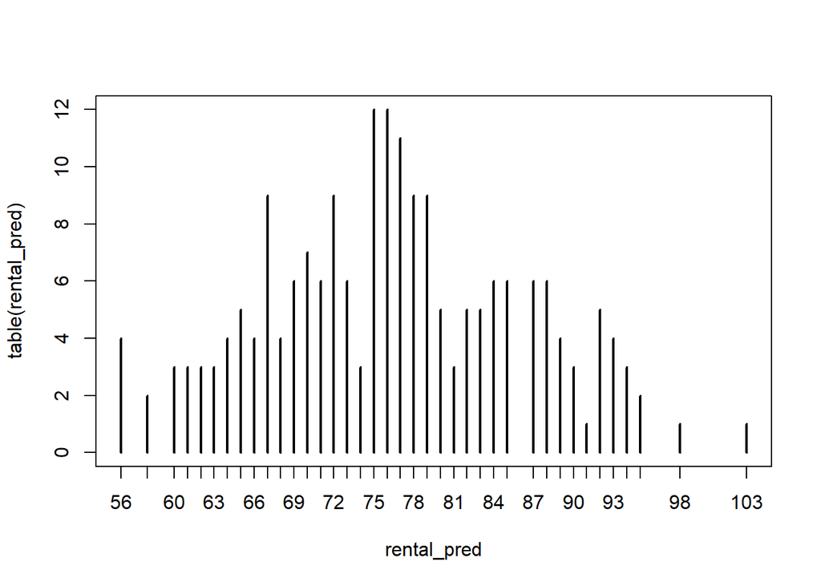

```r
plot(table(rental_pred))
```

We can also try to build our model with OpenBugs package and compare it with the one obtained with MCMCpack.

```r
library(R2OpenBUGS)
pois.bayes <- function(){
  for( i in 1 : n ) {
    rentals[i] ~ dpois(lambda[i])
    log(lambda[i]) <- b0 + b1 * datetimeEvening[i] + b2*datetimeMorning[i] + b3*datetimeNight[i] + b4*season2[i] + b5*season3[i] + b6*season4[i] + b7*workingday1[i] + b8*weather2[i] + b9*weather3[i] + b10*weather4[i] + b11*registered[i] + b12*casual[i] +
b13*holiday1[i]
  }
  b0 ~ dnorm(0.0, 1.0E-6)
  b1 ~ dnorm(0.0, 1.0E-6)
  b2 ~ dnorm(0.0, 1.0E-6)
  b3 ~ dnorm(0.0, 1.0E-6)
  b4 ~ dnorm(0.0, 1.0E-6)
  b5 ~ dnorm(0.0, 1.0E-6)
  b6 ~ dnorm(0.0, 1.0E-6)
  b7 ~ dnorm(0.0, 1.0E-6)
  b8 ~ dnorm(0.0, 1.0E-6)
  b9 ~ dnorm(0.0, 1.0E-6)
  b10 ~ dnorm(0.0, 1.0E-6)
  b11 ~ dnorm(0.0, 1.0E-6)
  b12 ~ dnorm(0.0, 1.0E-6)
  b13 ~ dnorm(0.0, 1.0E-6)

}
n=length(data$count)
datetimeEvening = ifelse(data$datetime=="Evening",1,0)
datetimeMorning = ifelse(data$datetime=="Morning",1,0)
datetimeNight = ifelse(data$datetime=="Night",1,0)
season2 = ifelse(data$season=="2",1,0)
season3 = ifelse(data$season=="3",1,0)
season4 = ifelse(data$season=="4",1,0)
workingday1 = ifelse(data$workingday=="1",1,0)
weather2 = ifelse(data$weather=="2",1,0)
weather3 = ifelse(data$weather=="3",1,0)
weather4 = ifelse(data$weather=="4",1,0)
holiday1 = ifelse(data$holiday=="1",1,0)
Data <- list(n=n, rentals=data$count, datetimeEvening = datetimeEvening,
             datetimeMorning = datetimeMorning, datetimeNight = datetimeNight,
             season2 = season2, season3 = season3, season4 = season4,
             workingday1 = workingday1, weather2 = weather2, weather3 = weather3,
             weather4 = weather4, registered = data$registered, casual = data$casual,
             holiday1=as.numeric(data$holiday))
inits <- function(){
  list(b0 = 1, b1 = 0, b2 = 0, b3 = 0, b4 = 1, b5 = 0, b6 = 0, b7 = 0, b8 = 1, b9 = 0, b10 = 0, b11 = 0, b12 = 0, b13 = 0)
}
output <- bugs(data = Data, inits = inits, parameters.to.save = c("b0", "b1", "b2","b3", "b4", "b5", "b6", "b7", "b8", "b9", "b10", "b11", "b12","b13"), model.file = pois.bayes, n.chains = 1, n.burnin=100, n.iter = 1000)
output
```

```
## Inference for Bugs model at "C:/Users/dtori/AppData/Local/Temp/RtmpaQjTVT/model4138274973e0.txt",
## Current: 1 chains, each with 1000 iterations (first 100 discarded)
## Cumulative: n.sims = 900 iterations saved
##              mean   sd     2.5%      25%      50%      75%    97.5%
## b0            4.3  0.0      4.3      4.3      4.3      4.3      4.4
## b1           -0.1  0.0     -0.1     -0.1     -0.1     -0.1     -0.1
## b2           -0.1  0.0     -0.1     -0.1     -0.1     -0.1     -0.1
## b3           -0.5  0.0     -0.5     -0.5     -0.5     -0.5     -0.5
## b4            0.1  0.0      0.1      0.1      0.1      0.1      0.1
## b5            0.1  0.0      0.1      0.1      0.1      0.1      0.1
## b6            0.1  0.0      0.1      0.1      0.1      0.1      0.1
## b7            0.0  0.0      0.0      0.0      0.0      0.0      0.0
## b8            0.0  0.0      0.0      0.0      0.0      0.0      0.0
## b9           -0.1  0.0     -0.1     -0.1     -0.1     -0.1     -0.1
## b10           0.2  0.1      0.1      0.2      0.2      0.3      0.4
## b11           0.0  0.0      0.0      0.0      0.0      0.0      0.0
## b12           0.0  0.0      0.0      0.0      0.0      0.0      0.0
## b13           0.0  0.0     -0.1      0.0      0.0      0.0      0.0
## deviance 306120.3 96.4 306100.0 306100.0 306100.0 306100.0 306400.0
##
## DIC info (using the rule, pD = Dbar-Dhat)
## pD = 34.3 and DIC = 306200.0
## DIC is an estimate of expected predictive error (lower deviance is better).
```

We can see that using OpenBugs we apparently obtain some coefficients equal to 0, but we have to check it because the summary of OpenBugs rounds the coefficients to one decimal.

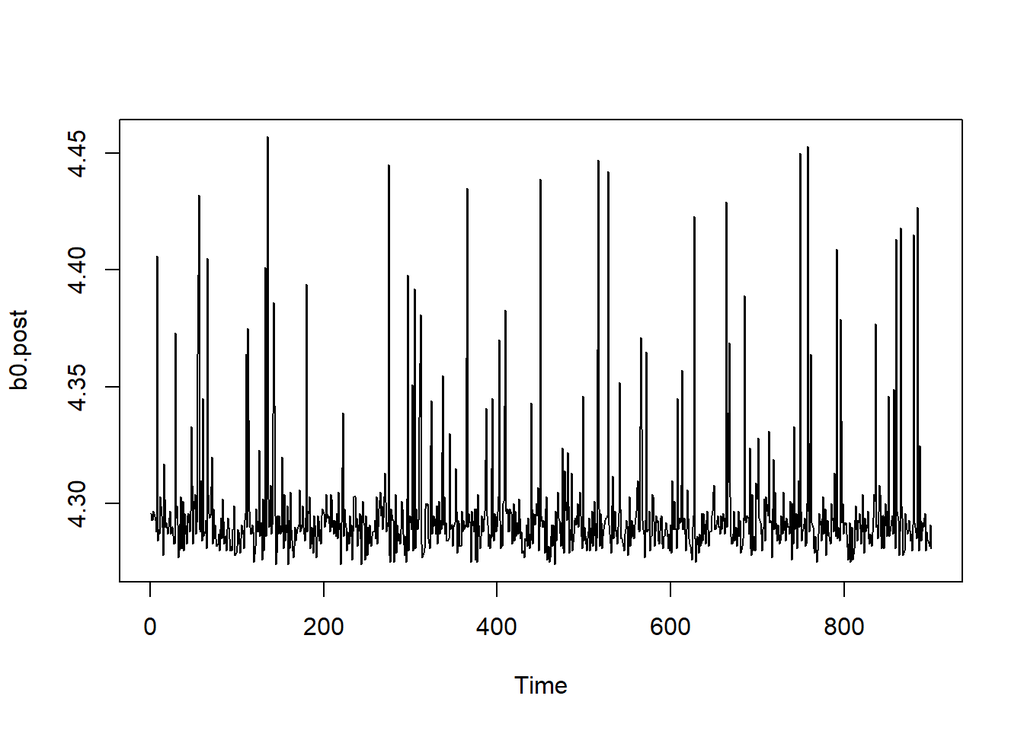

```r
b0.post <-output$sims.list$b0
b1.post <-output$sims.list$b1
b2.post <-output$sims.list$b2
b3.post <-output$sims.list$b3
b4.post <-output$sims.list$b4
b5.post <-output$sims.list$b5
b6.post <-output$sims.list$b6
b7.post <-output$sims.list$b7
b8.post <-output$sims.list$b8
b9.post <-output$sims.list$b9
b10.post <-output$sims.list$b10
b11.post <-output$sims.list$b11
b12.post <-output$sims.list$b12
ts.plot(b0.post)
```

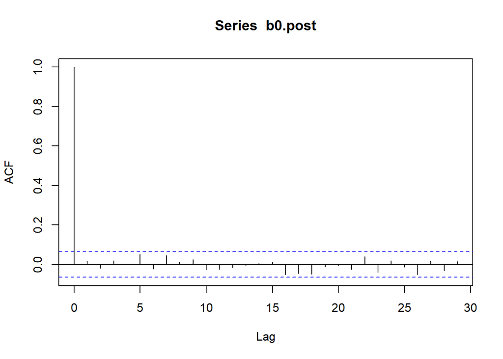

```r
acf(b0.post)
```

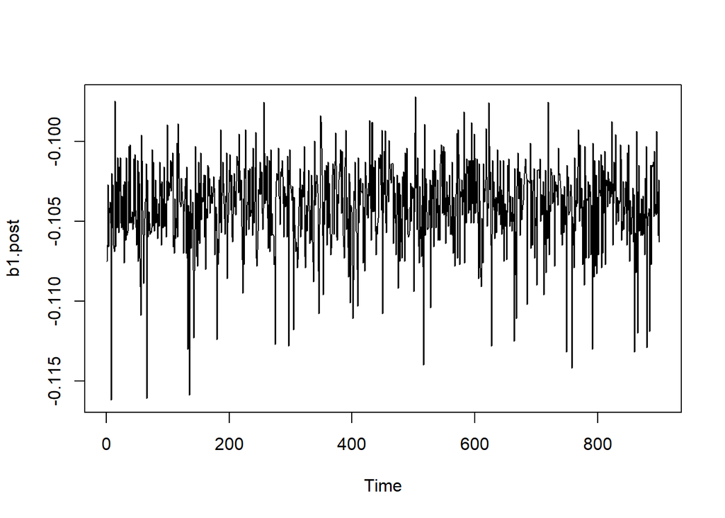

```r
ts.plot(b1.post)
```

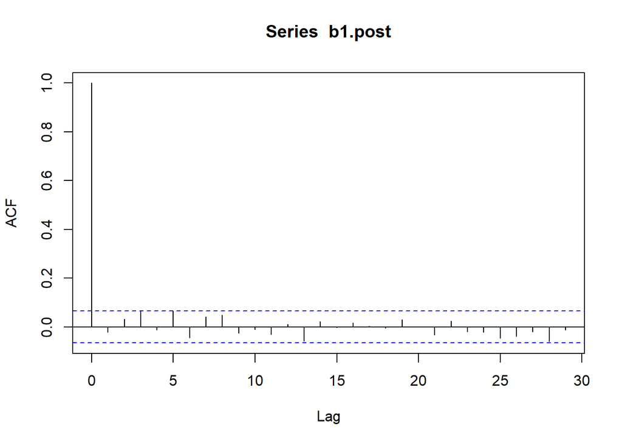

```r
acf(b1.post)
```

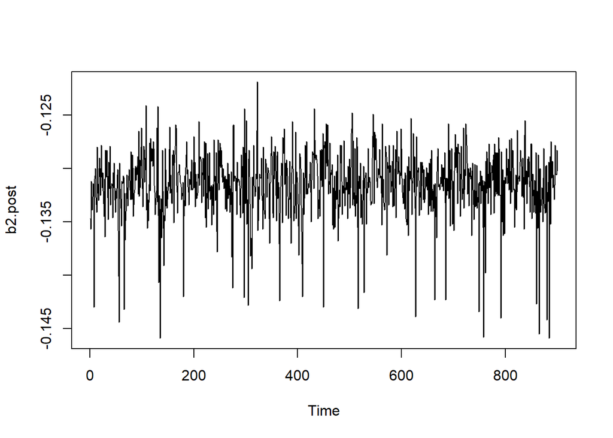

```r
ts.plot(b2.post)
```

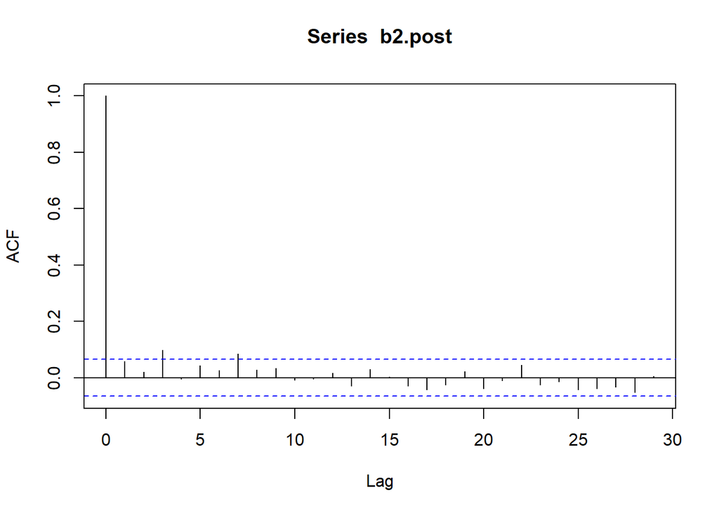

```r
acf(b2.post)
```

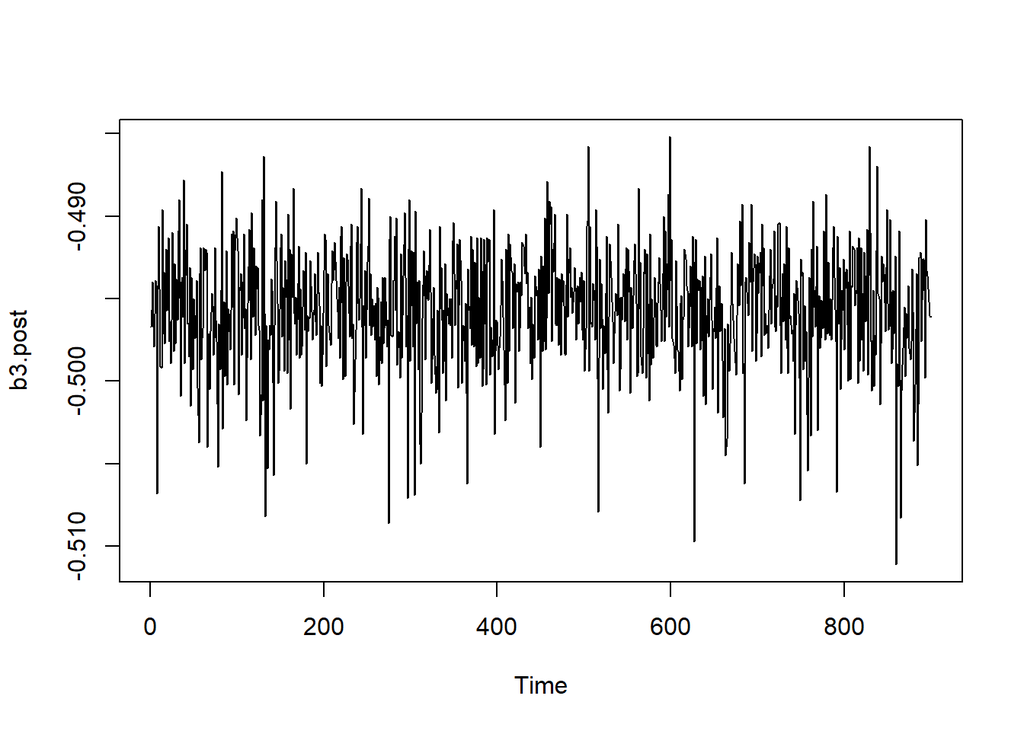

```r
ts.plot(b3.post)
```

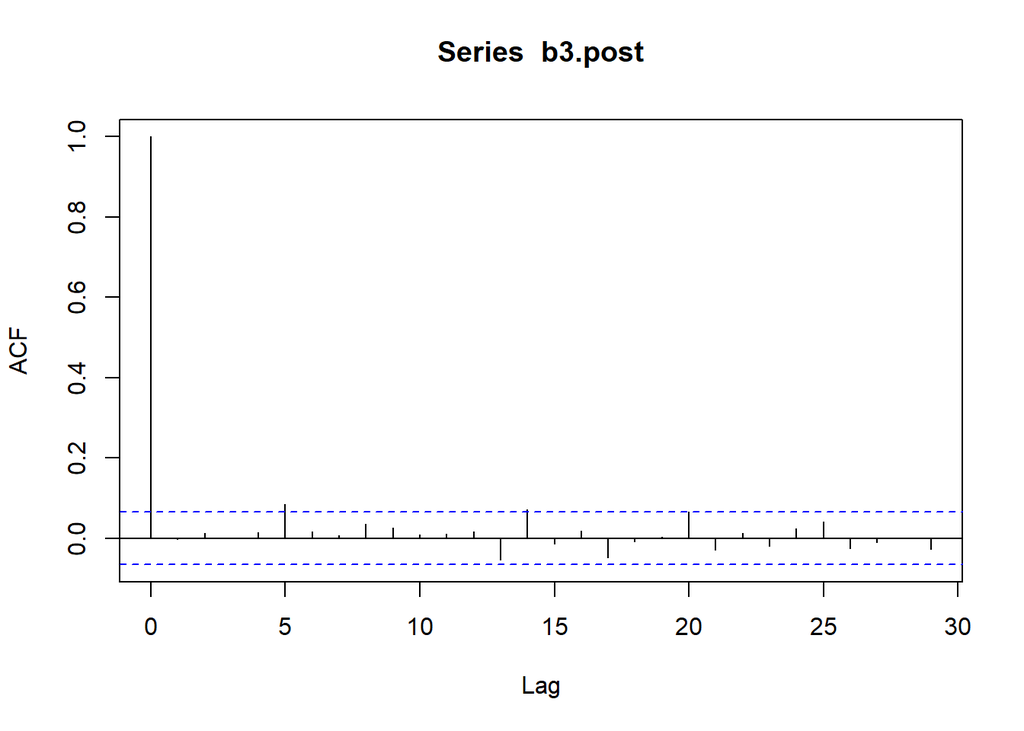

```r
acf(b3.post)
```

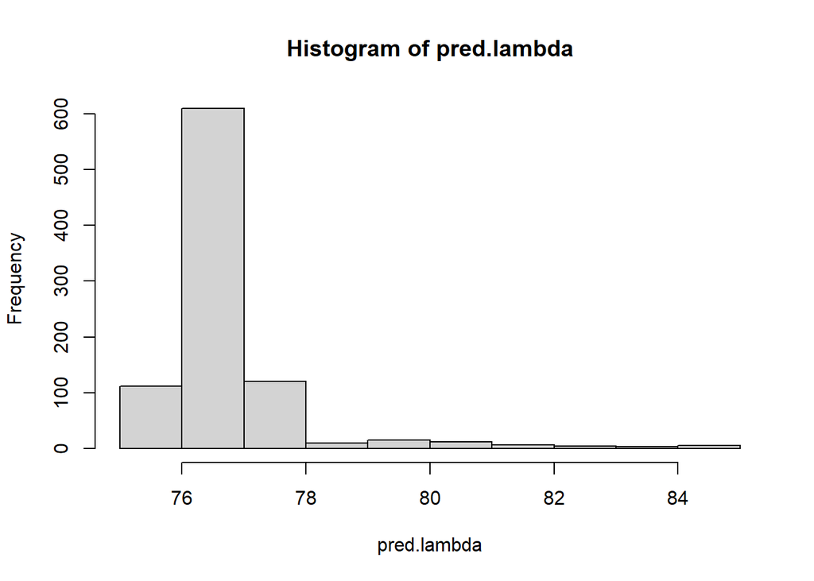

```r
pred.lambda=exp(b0.post+b2.post+b5.post+b7.post+b8.post+7*b11.post+5*b12.post)
hist(pred.lambda)
```

```r
mean(pred.lambda)
```

```
## [1] 76.79417
```

```r
quantile(pred.lambda,c(0.025,0.975))
```

```
##     2.5%    97.5%
## 75.69919 80.72783
```

```r
pred.rentals =rpois(length(pred.lambda),pred.lambda)
quantile(pred.rentals,c(0.025,0.975))
```

```
##   2.5%  97.5%
## 60.475 95.000
```

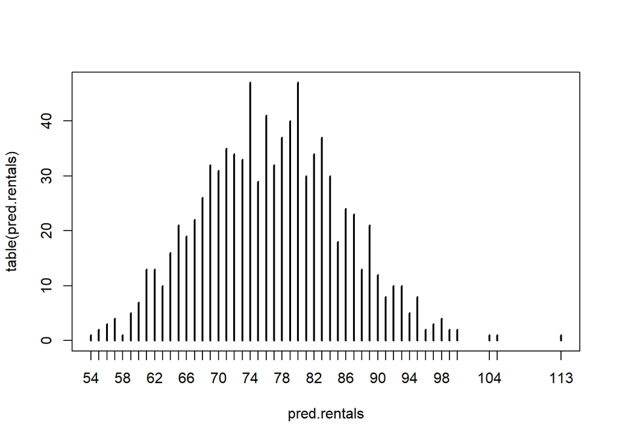

```r
plot(table(pred.rentals))
```

```r
c(mean(rental_pred),mean(pred.rentals))
```

```
## [1] 76.31000 76.78444
```

We obtain almost the same results but we can build another model without weather2 and holiday1 because the zero was contained in its coefficient credible interval.

```r
pois.bayes <- function(){
  for( i in 1 : n ) {
    rentals[i] ~ dpois(lambda[i])
    log(lambda[i]) <- b0 + b1 * datetimeEvening[i] + b2*datetimeMorning[i] + b3*datetimeNight[i] + b4*season2[i] + b5*season3[i] + b6*season4[i] + b7*workingday1[i]  + b8*weather3[i] + b9*weather4[i] + b10*registered[i] + b11*casual[i]
  }
  b0 ~ dnorm(0.0, 1.0E-6)
  b1 ~ dnorm(0.0, 1.0E-6)
  b2 ~ dnorm(0.0, 1.0E-6)
  b3 ~ dnorm(0.0, 1.0E-6)
  b4 ~ dnorm(0.0, 1.0E-6)
  b5 ~ dnorm(0.0, 1.0E-6)
  b6 ~ dnorm(0.0, 1.0E-6)
  b7 ~ dnorm(0.0, 1.0E-6)
  b8 ~ dnorm(0.0, 1.0E-6)
  b9 ~ dnorm(0.0, 1.0E-6)
  b10 ~ dnorm(0.0, 1.0E-6)
  b11 ~ dnorm(0.0, 1.0E-6)

}
n=length(data$count)
datetimeEvening = ifelse(data$datetime=="Evening",1,0)
datetimeMorning = ifelse(data$datetime=="Morning",1,0)
datetimeNight = ifelse(data$datetime=="Night",1,0)
season2 = ifelse(data$season=="2",1,0)
season3 = ifelse(data$season=="3",1,0)
season4 = ifelse(data$season=="4",1,0)
workingday1 = ifelse(data$workingday=="1",1,0)
weather3 = ifelse(data$weather=="3",1,0)
weather4 = ifelse(data$weather=="4",1,0)
Data <- list(n=n, rentals=data$count, datetimeEvening = datetimeEvening,
             datetimeMorning = datetimeMorning, datetimeNight = datetimeNight,
             season2 = season2, season3 = season3, season4 = season4,
             workingday1 = workingday1, weather3 = weather3,
             weather4 = weather4, registered = data$registered, casual = data$casual)
inits <- function(){
  list(b0 = 1, b1 = 0, b2 = 0, b3 = 0, b4 = 1, b5 = 0, b6 = 0, b7 = 0, b8 = 1, b9 = 0, b10 = 0, b11 = 0)
}
output2 <- bugs(data = Data, inits = inits, parameters.to.save = c("b0", "b1", "b2","b3", "b4", "b5", "b6", "b7", "b8", "b9", "b10", "b11"), model.file = pois.bayes, n.chains = 1, n.burnin=100, n.iter = 1000)
output2
```

```
## Inference for Bugs model at "C:/Users/dtori/AppData/Local/Temp/RtmpaQjTVT/model4138799c436a.txt",
## Current: 1 chains, each with 1000 iterations (first 100 discarded)
## Cumulative: n.sims = 900 iterations saved
##              mean  sd     2.5%      25%      50%      75%    97.5%
## b0            4.3 0.0      4.3      4.3      4.3      4.3      4.3
## b1           -0.1 0.0     -0.1     -0.1     -0.1     -0.1     -0.1
## b2           -0.1 0.0     -0.1     -0.1     -0.1     -0.1     -0.1
## b3           -0.5 0.0     -0.5     -0.5     -0.5     -0.5     -0.5
## b4            0.1 0.0      0.1      0.1      0.1      0.1      0.1
## b5            0.1 0.0      0.1      0.1      0.1      0.1      0.1
## b6            0.1 0.0      0.1      0.1      0.1      0.1      0.1
## b7            0.0 0.0      0.0      0.0      0.0      0.0      0.0
## b8           -0.1 0.0     -0.1     -0.1     -0.1     -0.1     -0.1
## b9            0.2 0.1      0.1      0.2      0.2      0.3      0.4
## b10           0.0 0.0      0.0      0.0      0.0      0.0      0.0
## b11           0.0 0.0      0.0      0.0      0.0      0.0      0.0
## deviance 306100.0 0.0 306100.0 306100.0 306100.0 306100.0 306100.0
##
## DIC info (using the rule, pD = Dbar-Dhat)
## pD = 11.8 and DIC = 306100.0
## DIC is an estimate of expected predictive error (lower deviance is better).
```

```r
pred.lambda2=exp(b0.post+b2.post+b5.post+b7.post+7*b10.post+5*b11.post)
pred.rentals2 =rpois(length(pred.lambda),pred.lambda)
quantile(pred.rentals2,c(0.025,0.975))
```

```
##  2.5% 97.5%
##    59    94
```

```r
c(mean(rental_pred),mean(pred.rentals),mean(pred.rentals2))
```

```
## [1] 76.31000 76.78444 76.67000
```

We can compare the models built woth OpenBugs using the DIC

```r
c(output$DIC,output2$DIC)
```

```
## [1] 306200 306100
```

We obtain lower DIC for the second model without weather2 and holiday1. This means that our final model is going to be the second one.

### Conclusion

We can see that when we use Bayesian Poisson regression our predictive confidence interval are narrower than when we just use Monte Carlo to approximate the predictive distribution. Also we can see that removing some variables, for example, holiday and weather2, reduces the DIC of the Poisson regression model.

In conclusion, Bayesian prediction provides us with a prediction distribution while the frequentist approach only gives us a point estimation.